# Trabalho de Séries Temporais

Arthur Bazolli, Marina Rocha e Matheus Wiermann

21/05/2021

# 1 Introdução

A série escolhida refere-se ao volume transportado em toneladas úteis pela Ferrovia Centro-Atlântica (FCA). A série vai de 2006 a 2020, com dados mensais, e foi complilada a partir do conjunto de dados abertos da Agência Nacional de Transportes Terrestres — ANTT, disponíveis [neste link](https://dados.antt.gov.br/dataset/sistema-de-acompanhamento-do-desempenho-operacional-das-concessionarias-siade).

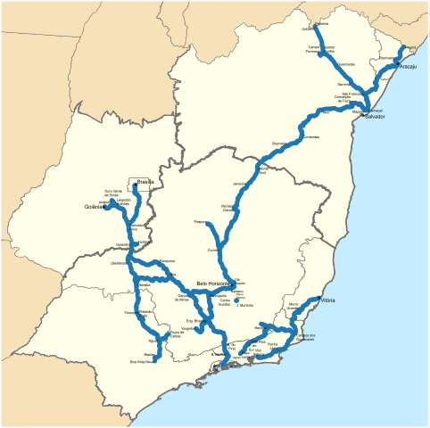

Figura 1: malha da FCA. A ferrovia interliga o Centro-Oeste e o Nordeste com Minas Gerais, onde a produção é escoada pelos portos de SP, RJ e ES pelas malhas da MRS e da EFVM.

# 2 Análise exploratória

```r
antt <- read_excel("C:/Users/arthu/OneDrive/Documentos/R/Projects/ECST/Atividade ECST/antt/producao_origem_destino.xlsx")
str(antt)
```

```
## tibble [130,193 x 9] (S3: tbl_df/tbl/data.frame)
##  $ Mes_Ano        : POSIXct[1:130193], format: "2006-01-01" "2006-01-01" ...
##  $ Ferrovia       : chr [1:130193] "EFC" "EFC" "EFC" "EFC" ...
##  $ Mercadoria_ANTT: chr [1:130193] "Álcool" "Bebidas e Vasilhames" "Cobre" "Ferro Gusa" ...
##  $ Estacao_Origem : chr [1:130193] "Itaqui Base Combustível" "Ponta da Madeira Pêra do Píer" "Paraupebas" "Açailândia" ...
##  $ UF_Origem      : chr [1:130193] "MA" "MA" "PA" "MA" ...
##  $ Estacao_Destino: chr [1:130193] "Marabá" "Imperatriz" "Ponta da Madeira Cobre" "Ponta da Madeira Pêra do Píer" ...
##  $ UF_Destino     : chr [1:130193] "PA" "MA" "MA" "MA" ...
##  $ TU             : num [1:130193] 184 1636 24461 116272 205242 ...
##  $ TKU            : num [1:130193] 1.36e+05 1.00e+06 2.12e+07 6.03e+07 1.53e+08 ...
```

```r
fca <- antt %>%
  dplyr::filter(Ferrovia == "FCA") %>%
  dplyr::select(Mes_Ano, TU, TKU) %>%
  mutate(TU = TU/1000000, TKU = TKU/1000000000) %>%
  group_by(Mes_Ano) %>%
  summarise_all(list(sum))

fca <- xts(fca[,-1], order.by = as.POSIXct(fca$Mes_Ano))

prod <- antt %>%
  dplyr::filter(Ferrovia == "FCA") %>%
  dplyr::select(Mercadoria_ANTT, TU, TKU) %>%
  group_by(Mercadoria_ANTT) %>%
  summarise(TU = sum(TU), TKU = sum(TKU)) %>%
  mutate(TU = TU/1000000, TKU = TKU/1000000000) %>%
  mutate(`Part. (%)` = 100*TU/sum(TU)) %>%
  arrange(desc(`Part. (%)`))

knitr::kable(prod[1:10,], digits = 2, align = "c")
```

| Mercadoria_ANTT | TU | TKU | Part. (%) |
| --- | --- | --- | --- |
| Soja | 62.85 | 73.54 | 17.18 |
| Minério de Ferro | 53.78 | 13.30 | 14.70 |
| Açúcar | 37.43 | 23.41 | 10.23 |
| Grãos - Milho | 33.54 | 40.07 | 9.17 |
| Calcário Siderúrgico | 27.79 | 12.63 | 7.60 |
| Bauxita | 27.29 | 10.50 | 7.46 |
| Farelo de Soja | 14.27 | 20.52 | 3.90 |
| Fosfato | 14.15 | 9.36 | 3.87 |
| Enxofre | 12.38 | 9.16 | 3.38 |
| Dolomita | 7.65 | 3.53 | 2.09 |

As estatísticas demonstram que os principais produtos transportados pela FCA são commodities agrícolas e minerais. Assim, é plausível imaginar que a série apresente alguma relação com o ciclo de produção de alguns desses bens, como a soja e o milho, bem como com as dinâmicas macroeconômicas dos países exportadores.

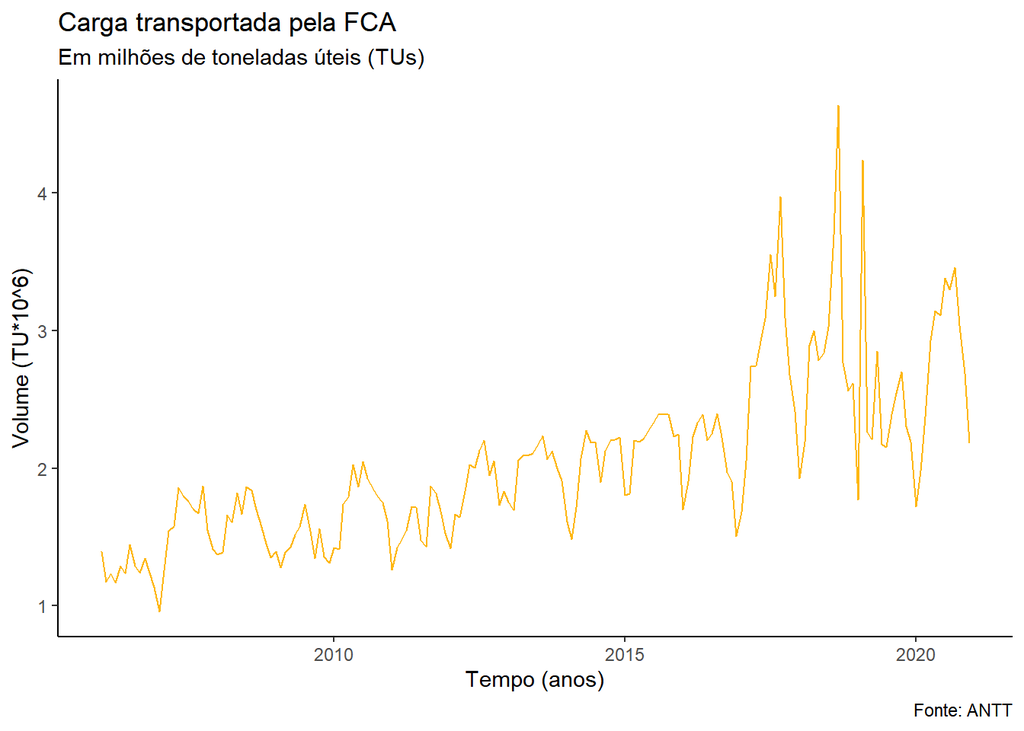

```r
ggplot(data = fca, aes(time(fca), TU, TKU)) +
  geom_line(color = "#FEB712") +
  theme(axis.text.x = element_text(angle = 90, hjust = 1)) +
  theme_classic() +
  labs(title = "Carga transportada pela FCA", subtitle = "Em milhões de toneladas úteis (TUs)", x = "Tempo (anos)", y = "Volume (TU*10^6)", caption = "Fonte: ANTT")
```

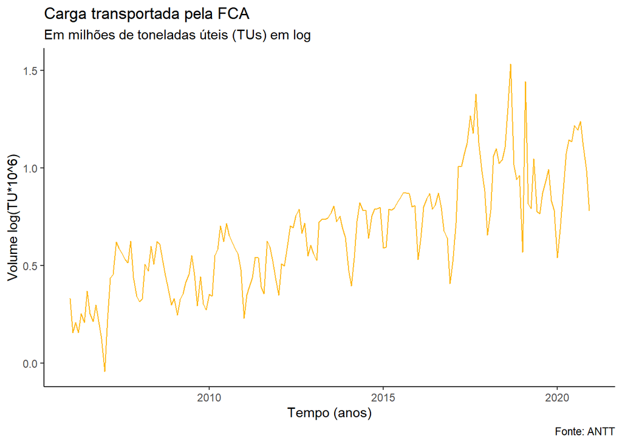

```r
fca_log <- log(fca)[,1]

ggplot(data = fca_log, aes(time(fca_log), TU)) +
  geom_line(color = "#FEB712") +
  theme(axis.text.x = element_text(angle = 90, hjust = 1)) +
  theme_classic() +
  labs(title = "Carga transportada pela FCA", subtitle = "Em milhões de toneladas úteis (TUs) em log", x = "Tempo (anos)", y = "Volume log(TU*10^6)", caption = "Fonte: ANTT")
```

## 2.1 Tendência e sazonalidade

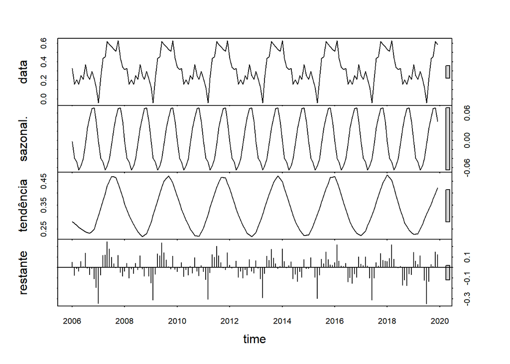

```r
tu_ts <- fca_log
tu_ts <- ts(tu_ts, start = c(2006,01,01), end = c(2019,12,01), frequency = 1)
tu_ts <- ts(tu_ts, start = c(2006,01,01), end = c(2019,12,01), frequency = 12)
decomp <- stl(tu_ts, "periodic")
colnames(decomp$time.series) = c("sazonal.","tendência","restante")
plot(decomp)
```

A decomposição da série indica a presença de sazonalidade e tendência semelhantes a uma senóide, com picos e vales, convergente com a intuição dos ciclos produtivos (oferta) e econômicos (demanda).

## 2.2 Teste de raiz unitária

$H_0$: presença de raiz unitária

$H_1$: ausença de raiz unitária

```r
# passeio aleatório
fUnitRoots::adfTest(fca_log, lags =12, type = c("nc"))
```

```
##
## Title:
##  Augmented Dickey-Fuller Test
##
## Test Results:
##   PARAMETER:
##     Lag Order: 12
##   STATISTIC:
##     Dickey-Fuller: 1.0425
##   P VALUE:
##     0.9187
##
## Description:
##  Mon May 24 08:19:10 2021 by user: arthu
```

```r
# passeio aleatório com drift
fUnitRoots::adfTest(fca_log, lags =12, type = c("c"))
```

```
##
## Title:
##  Augmented Dickey-Fuller Test
##
## Test Results:
##   PARAMETER:
##     Lag Order: 12
##   STATISTIC:
##     Dickey-Fuller: -1.9337
##   P VALUE:
##     0.338
##
## Description:
##  Mon May 24 08:19:10 2021 by user: arthu
```

```r
# passeio aleatório com constante e tendência
fUnitRoots::adfTest(fca_log, lags =12, type = c("ct"))
```

```
##
## Title:
##  Augmented Dickey-Fuller Test
##
## Test Results:
##   PARAMETER:
##     Lag Order: 12
##   STATISTIC:
##     Dickey-Fuller: -3.5075
##   P VALUE:
##     0.04368
##
## Description:
##  Mon May 24 08:19:10 2021 by user: arthu
```

O teste para presença de raiz unitária considerando um modelo de passeio aleatório não é rejeitado, com p-valor de aproximadamente 0,92. Sob a premissa de passeio aleatório com drift, o p-valor diminui para cerca de 0,34, ainda não rejeitado. Já no caso do passeio aleatório com constante e tendência, é possível rejeitar a possibilidade de raiz unitária a um nível crítico de 5%, o que indica que a série pode se comportar como um passeio aleatório dessa natureza.

# 3 Análise das FAC e FACP

## 3.1 Modelo original

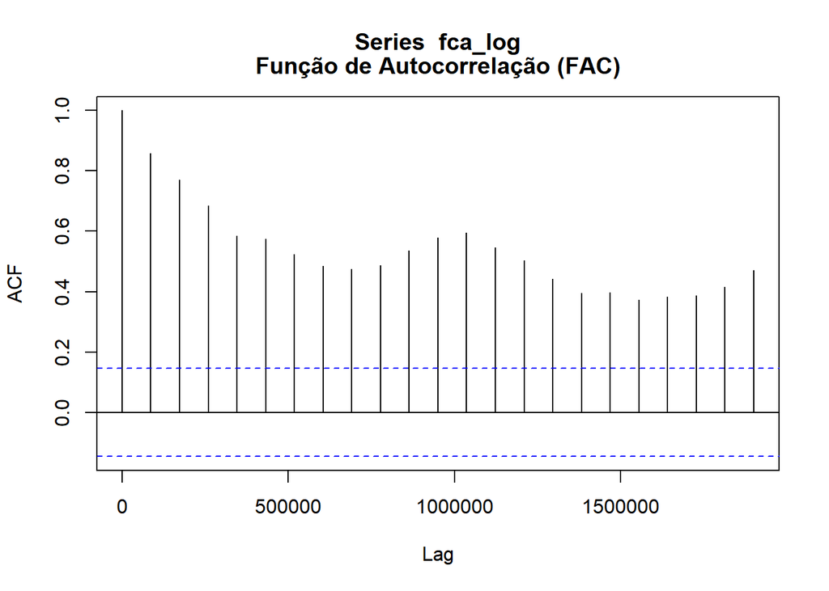

```r
fac_logFca <- stats::acf(fca_log, plot = FALSE, na.action = na.pass)

par(mfrow=c(1,1))
plot(fac_logFca)
title("Função de Autocorrelação (FAC)", adj = 0.5, line = 1)
```

O padrão da FAC — correlação significativa persistente — indica que a série é não estacionária e, possivelmente, sazonal. Assim, é necessário fazer a primeira diferenciação para expurgar a tendência.

## 3.2 Uma diferença

```r
logFca_dif <-timeSeries::diff(fca_log, lag = 1, differences = 1)

m <- logFca_dif %>%
  na.omit() %>%
  mean()
m
```

```
## [1] 0.002509738
```

```r
logFca_dif %>%
  na.omit() %>%
  var()
```

```
##            TU
## TU 0.02252455
```

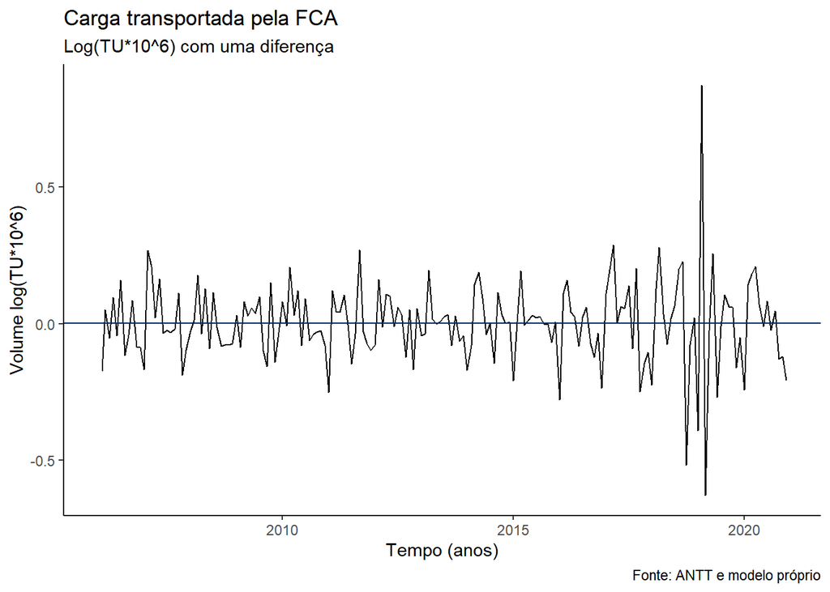

```r
ggplot(data = logFca_dif, aes(x=time(logFca_dif), y = TU)) +
  geom_line() +
  geom_hline(yintercept = m, color = "#002C5E") +
  labs(title = "Carga transportada pela FCA", subtitle = "Log(TU*10^6) com uma diferença", x = "Tempo (anos)", y = "Volume log(TU*10^6)", caption = "Fonte: ANTT e modelo próprio") +
  theme(axis.text.x = element_text(angle = 90, hjust = 1)) +
  theme_classic()
```

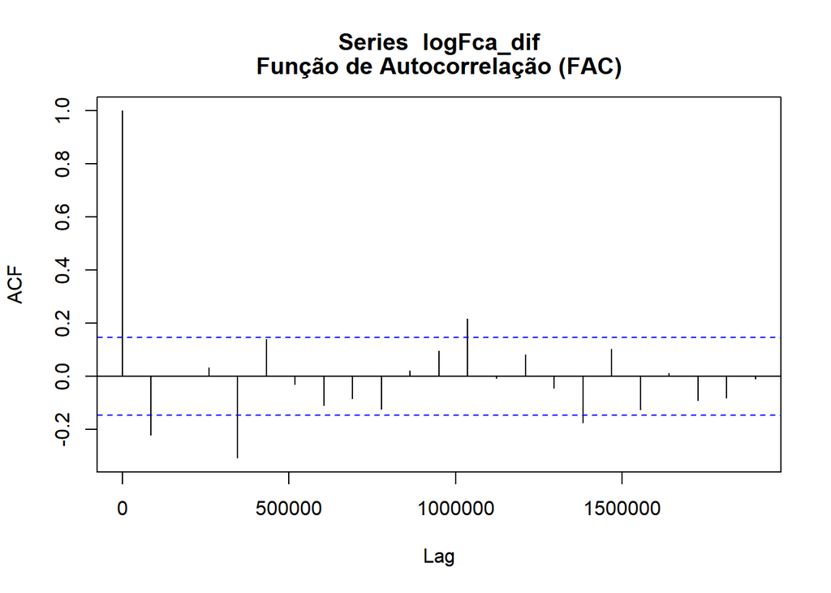

```r
fac_logFca_dif <- stats::acf(logFca_dif, plot = FALSE, na.action = na.pass)
plot(fac_logFca_dif)
title("Função de Autocorrelação (FAC)", adj = 0.5, line = 1)
```

Após a primeira diferenciação, a série aparenta ter um padrão estacionário. Além disso, sua FAC tem menos lags significativos.

```r
adfTest(logFca_dif, lags = 12, type = "nc")
```

```
##
## Title:
##  Augmented Dickey-Fuller Test
##
## Test Results:
##   PARAMETER:
##     Lag Order: 12
##   STATISTIC:
##     Dickey-Fuller: -4.8244
##   P VALUE:
##     0.01
##
## Description:
##  Mon May 24 08:19:12 2021 by user: arthu
```

```r
adfTest(logFca_dif, lags = 12, type = "c")
```

```
##
## Title:
##  Augmented Dickey-Fuller Test
##
## Test Results:
##   PARAMETER:
##     Lag Order: 12
##   STATISTIC:
##     Dickey-Fuller: -5.0785
##   P VALUE:
##     0.01
##
## Description:
##  Mon May 24 08:19:12 2021 by user: arthu
```

```r
adfTest(logFca_dif, lags = 12, type = "ct")
```

```
##
## Title:
##  Augmented Dickey-Fuller Test
##
## Test Results:
##   PARAMETER:
##     Lag Order: 12
##   STATISTIC:
##     Dickey-Fuller: -5.1021
##   P VALUE:
##     0.01
##
## Description:
##  Mon May 24 08:19:12 2021 by user: arthu
```

Os testes de raiz unitária rejeitam a hipótese de o modelo se comportar como um passeio aleatório.

## 3.3 Sazonalidade e diferença

```r
logFca_dif_saz3 <- timeSeries::diff(timeSeries::diff(fca_log, lag = 1, differences = 1), lag = 3, differences = 1, lag.max = 120)

m <- logFca_dif_saz3 %>%
  na.omit() %>%
  mean()
m
```

```
## [1] -0.001622879
```

```r
logFca_dif_saz3 %>%
  na.omit() %>%
  var()
```

```
##            TU
## TU 0.04367757
```

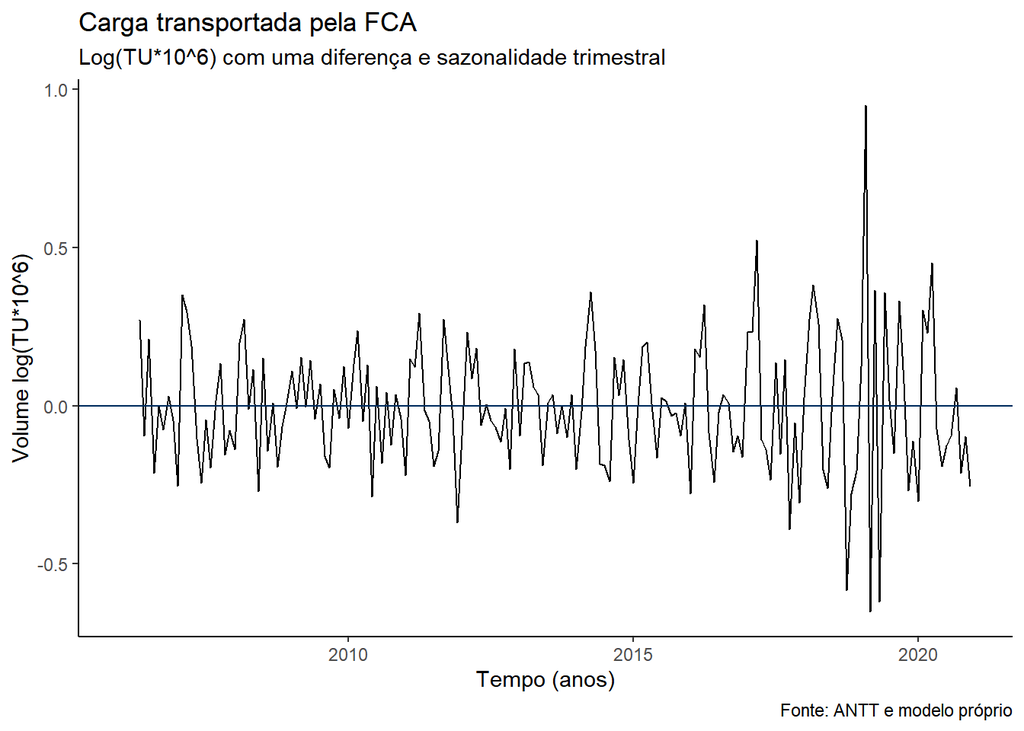

```r
ggplot(data = logFca_dif_saz3, aes(x=time(logFca_dif_saz3), y = TU)) +
  geom_line() +
  labs(title = "Carga transportada pela FCA", subtitle = "Log(TU*10^6) com uma diferença e sazonalidade trimestral", x = "Tempo (anos)", y = "Volume log(TU*10^6)", caption = "Fonte: ANTT e modelo próprio") +
  theme(axis.text.x = element_text(angle = 90, hjust = 1)) +
  theme_classic() +
  geom_hline(yintercept = m, color = "#002C5E")
```

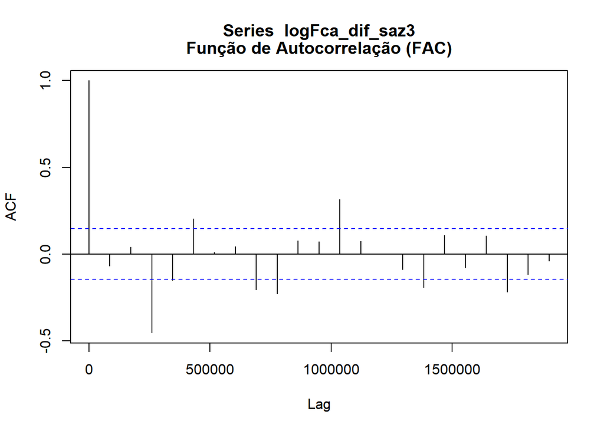

```r
fac_logFca_dif_saz3 <- stats::acf(logFca_dif_saz3, plot = FALSE, na.action = na.pass)
plot(fac_logFca_dif_saz3)
title("Função de Autocorrelação (FAC)", adj = 0.5, line = 1)
```

```r
adfTest(logFca_dif_saz3, lags = 12, type = "nc")
```

```
##
## Title:
##  Augmented Dickey-Fuller Test
##
## Test Results:
##   PARAMETER:
##     Lag Order: 12
##   STATISTIC:
##     Dickey-Fuller: -7.624
##   P VALUE:
##     0.01
##
## Description:
##  Mon May 24 08:19:13 2021 by user: arthu
```

```r
adfTest(logFca_dif_saz3, lags = 12, type = "c")
```

```
##
## Title:
##  Augmented Dickey-Fuller Test
##
## Test Results:
##   PARAMETER:
##     Lag Order: 12
##   STATISTIC:
##     Dickey-Fuller: -7.5941
##   P VALUE:
##     0.01
##
## Description:
##  Mon May 24 08:19:13 2021 by user: arthu
```

```r
adfTest(logFca_dif_saz3, lags = 12, type = "ct")
```

```
##
## Title:
##  Augmented Dickey-Fuller Test
##
## Test Results:
##   PARAMETER:
##     Lag Order: 12
##   STATISTIC:
##     Dickey-Fuller: -7.5802
##   P VALUE:
##     0.01
##
## Description:
##  Mon May 24 08:19:13 2021 by user: arthu
```

```r
logFca_dif_saz6 <- timeSeries::diff(timeSeries::diff(fca_log, lag = 1, differences = 1), lag = 6, differences = 1, lag.max = 120)

m <- logFca_dif_saz6 %>%
  na.omit() %>%
  mean()
m
```

```
## [1] -0.002272344
```

```r
logFca_dif_saz6 %>%
  na.omit() %>%
  var()
```

```
##           TU
## TU 0.0471491
```

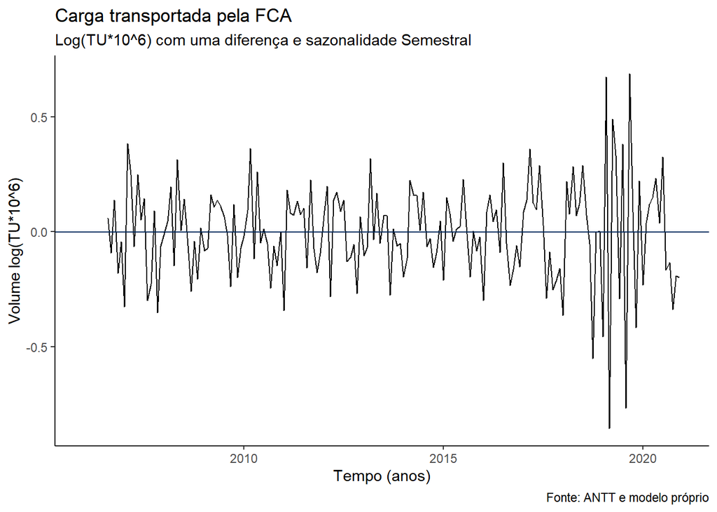

```r
ggplot(data = logFca_dif_saz6, aes(x=time(logFca_dif_saz6), y = TU)) +
  geom_line() +
  labs(title = "Carga transportada pela FCA", subtitle = "Log(TU*10^6) com uma diferença e sazonalidade Semestral", x = "Tempo (anos)", y = "Volume log(TU*10^6)", caption = "Fonte: ANTT e modelo próprio") +
  theme(axis.text.x = element_text(angle = 90, hjust = 1)) +
  theme_classic() +
  geom_hline(yintercept = m, color = "#002C5E")
```

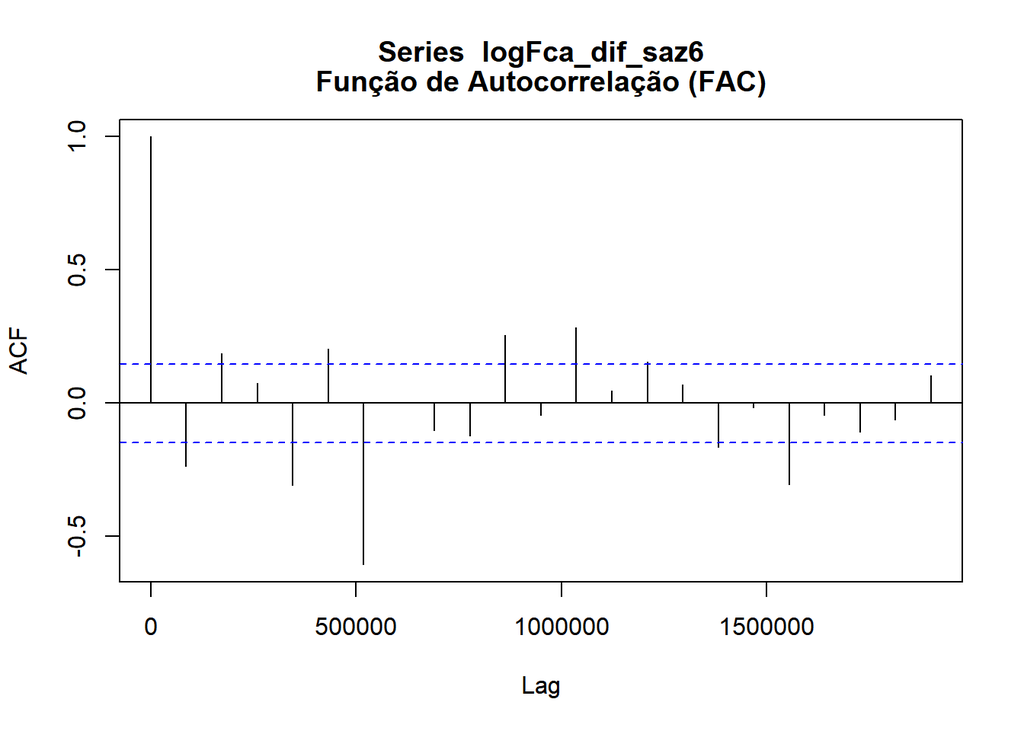

```r
fac_logFca_dif_saz6 <- stats::acf(logFca_dif_saz6, plot = FALSE, na.action = na.pass)
plot(fac_logFca_dif_saz6)
title("Função de Autocorrelação (FAC)", adj = 0.5, line = 1)
```

```r
adfTest(logFca_dif_saz6, lags = 12, type = "nc")
```

```
##
## Title:
##  Augmented Dickey-Fuller Test
##
## Test Results:
##   PARAMETER:
##     Lag Order: 12
##   STATISTIC:
##     Dickey-Fuller: -5.8358
##   P VALUE:
##     0.01
##
## Description:
##  Mon May 24 08:19:14 2021 by user: arthu
```

```r
adfTest(logFca_dif_saz6, lags = 12, type = "c")
```

```
##
## Title:
##  Augmented Dickey-Fuller Test
##
## Test Results:
##   PARAMETER:
##     Lag Order: 12
##   STATISTIC:
##     Dickey-Fuller: -5.815
##   P VALUE:
##     0.01
##
## Description:
##  Mon May 24 08:19:14 2021 by user: arthu
```

```r
adfTest(logFca_dif_saz6, lags = 12, type = "ct")
```

```
##
## Title:
##  Augmented Dickey-Fuller Test
##
## Test Results:
##   PARAMETER:
##     Lag Order: 12
##   STATISTIC:
##     Dickey-Fuller: -5.7924
##   P VALUE:
##     0.01
##
## Description:
##  Mon May 24 08:19:14 2021 by user: arthu
```

```r
logFca_dif_saz12 <- timeSeries::diff(timeSeries::diff(fca_log, lag = 1, differences = 1), lag = 12, differences = 1, lag.max = 120)

m <- logFca_dif_saz12 %>%
  na.omit() %>%
  mean()
m
```

```
## [1] 0.00221327
```

```r
logFca_dif_saz12 %>%
  na.omit() %>%
  var()
```

```
##            TU
## TU 0.03547031
```

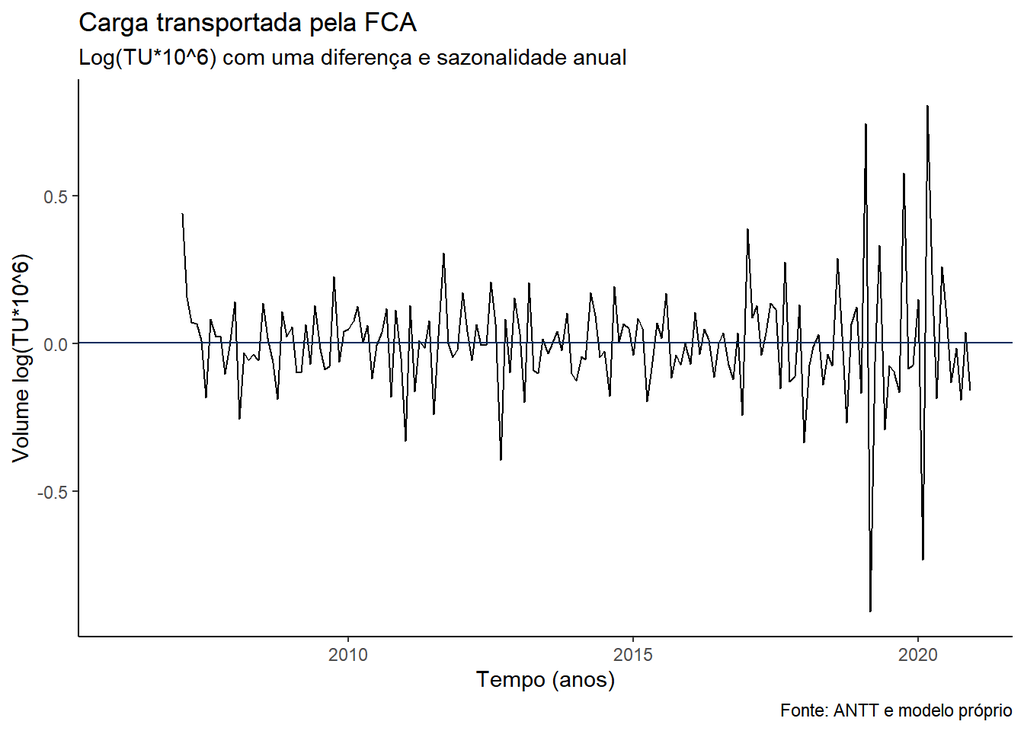

```r
ggplot(data = logFca_dif_saz12, aes(x=time(logFca_dif_saz12), y = TU)) +
  geom_line() +
  labs(title = "Carga transportada pela FCA", subtitle = "Log(TU*10^6) com uma diferença e sazonalidade anual", x = "Tempo (anos)", y = "Volume log(TU*10^6)", caption = "Fonte: ANTT e modelo próprio") +
  theme(axis.text.x = element_text(angle = 90, hjust = 1)) +
  theme_classic() +
  geom_hline(yintercept = m, color = "#002C5E")
```

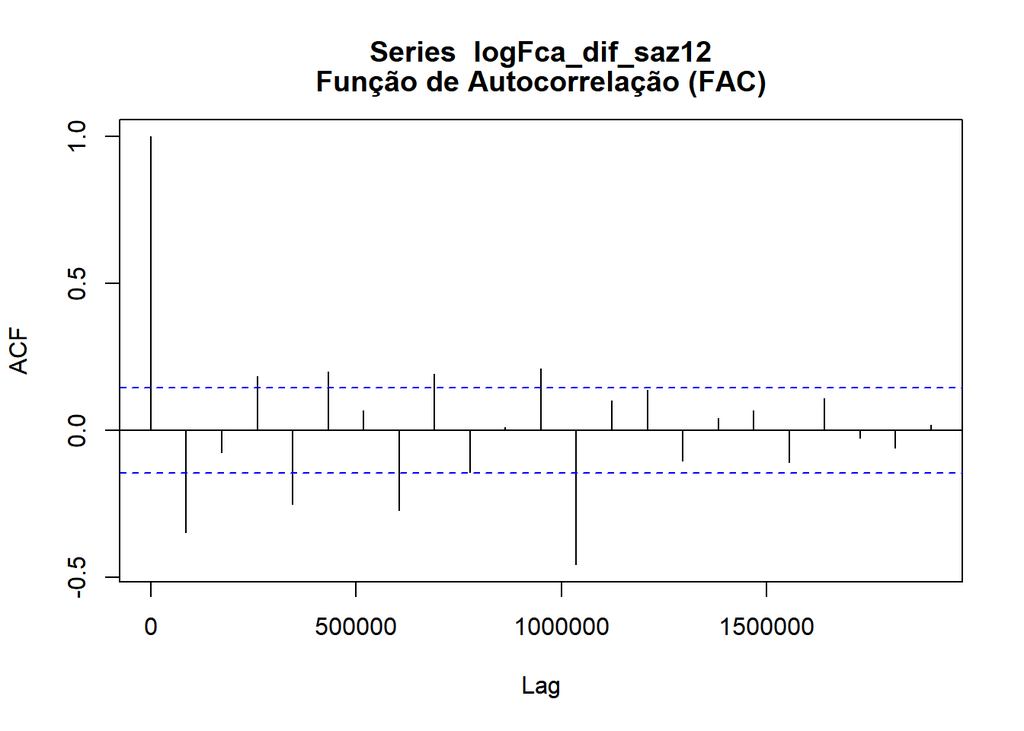

```r
fac_logFca_dif_saz12 <- stats::acf(logFca_dif_saz12, plot = FALSE, na.action = na.pass)
plot(fac_logFca_dif_saz12)
title("Função de Autocorrelação (FAC)", adj = 0.5, line = 1)
```

```r
adfTest(logFca_dif_saz12, lags = 12, type = "nc")
```

```
##
## Title:
##  Augmented Dickey-Fuller Test
##
## Test Results:
##   PARAMETER:
##     Lag Order: 12
##   STATISTIC:
##     Dickey-Fuller: -6.7373
##   P VALUE:
##     0.01
##
## Description:
##  Mon May 24 08:19:15 2021 by user: arthu
```

```r
adfTest(logFca_dif_saz12, lags = 12, type = "c")
```

```
##
## Title:
##  Augmented Dickey-Fuller Test
##
## Test Results:
##   PARAMETER:
##     Lag Order: 12
##   STATISTIC:
##     Dickey-Fuller: -6.7206
##   P VALUE:
##     0.01
##
## Description:
##  Mon May 24 08:19:15 2021 by user: arthu
```

```r
adfTest(logFca_dif_saz12, lags = 12, type = "ct")
```

```
##
## Title:
##  Augmented Dickey-Fuller Test
##
## Test Results:
##   PARAMETER:
##     Lag Order: 12
##   STATISTIC:
##     Dickey-Fuller: -6.6829
##   P VALUE:
##     0.01
##
## Description:
##  Mon May 24 08:19:15 2021 by user: arthu
```

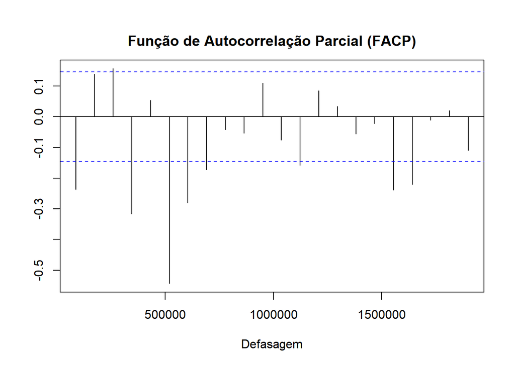

```r
# Sazonal 6 meses
facp_logFca_dif_saz6 <- stats::pacf(logFca_dif_saz6, plot = FALSE, na.action = na.pass)

plot(facp_logFca_dif_saz6, main = "", ylab = "", xlab = "Defasagem")
title("Função de Autocorrelação Parcial (FACP)", adj = 0.5, line = 1)
```

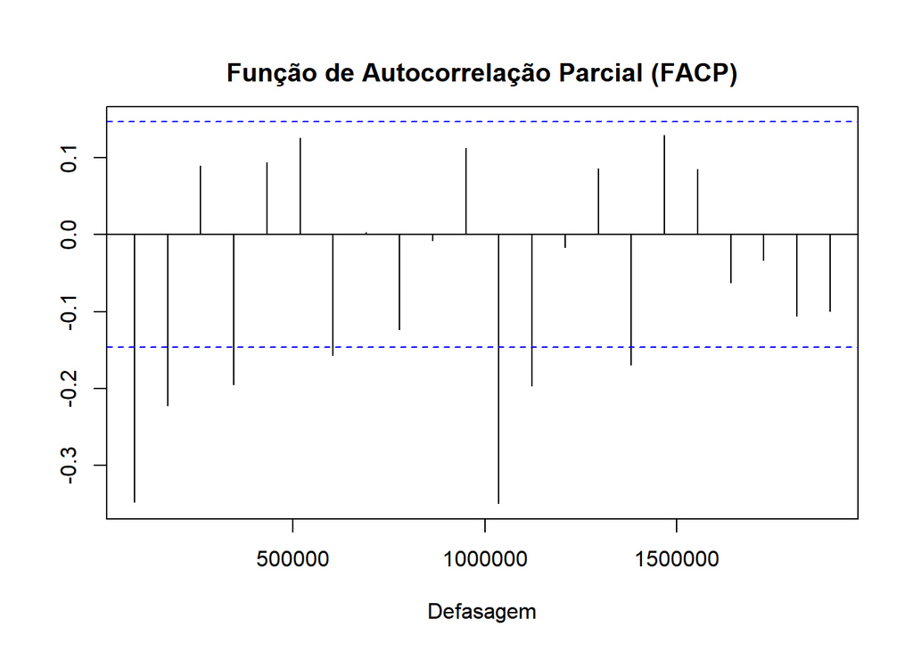

```r
# Sazonal 12 meses
facp_logFca_dif_saz12 <- stats::pacf(logFca_dif_saz12, plot = FALSE, na.action = na.pass)

plot(facp_logFca_dif_saz12, main = "", ylab = "", xlab = "Defasagem")
title("Função de Autocorrelação Parcial (FACP)", adj = 0.5, line = 1)
```

# 4 Estimação

## 4.1 Combinações de modelos

```r
# Todas as combinações possíveis de p=0 até p=max e q=0 até q=max para a parte não sazonal e P=0 até P=max e Q=0 até Q=max para a parte sazonal
pars_fca <- expand.grid(ar = 0:2, diff = 0:1, ma = 0:1, ars = 0:1, diffs = 0:1, mas = 0:1)

# Local onde os resultados de cada modelo será armazenado
modelo_fca <- list()

# Estimar os parâmetros dos modelos usando Máxima Verossimilhança (ML). Por default, a função arima usa a hipótese de que o termo de erro dos modelos arima segue uma distribuição Normal
for (i in 1:nrow(pars_fca)) {
  modelo_fca[[i]] <- arima(x = fca_log, order = unlist(pars_fca[i, 1:3]),
                                      seasonal = list(order = unlist(pars_fca[i,4:6]), period = 12), method = "ML")
}

# Obter o logaritmo da verossimilhança (valor máximo da função)
logVero_fca <- list()
for (i in 1:length(modelo_fca)) {
  logVero_fca[[i]] <- modelo_fca[[i]]$loglik
}

# Calcular o AIC
aicsarima_fca <- list()
for (i in 1:length(modelo_fca)) {
  aicsarima_fca[[i]] <- stats::AIC(modelo_fca[[i]])
}

# Calcular o BIC
bicsarima_fca <- list()
for (i in 1:length(modelo_fca)) {
  bicsarima_fca[[i]] <- stats::BIC(modelo_fca[[i]])
}

# Quantidade de parâmetros estimados por modelo
paramentros_fca <- list()
for (i in 1:length(modelo_fca)) {
  paramentros_fca[[i]] <- length(modelo_fca[[i]]$coef)+1 # +1 porque temos a variância do termo de erro
}
```

```r
# Montar a tabela com os resultados
espec_fca <- paste0("Sarima (",pars_fca$ar, ",", pars_fca$diff, ",", pars_fca$ma, ") ", "(", pars_fca$ars, ",", pars_fca$diffs, ",", pars_fca$mas,")")
amostra_fca <- rep(length(fca_log), length(modelo_fca))
resultado_fca <- data.frame(`Nº` = index(espec_fca),
                            Especificação = espec_fca,
                            ln_lik = unlist(logVero_fca),
                            Parâmetros = unlist(paramentros_fca),
                            Amostra = amostra_fca,
                            AIC = unlist(aicsarima_fca),
                            BIC = unlist(bicsarima_fca))
resultado_fca_rank <- resultado_fca %>%
  arrange(BIC)

# Mostrar a tabela de resultado
knitr::kable(resultado_fca_rank[1:10,], digits = 2, align = "c")
```

| Nº | Especificação | ln_lik | Parâmetros | Amostra | AIC | BIC |
| --- | --- | --- | --- | --- | --- | --- |
| 70 | Sarima (0,1,1) (1,0,1) | 112.37 | 4 | 180 | -216.73 | -203.98 |
| 71 | Sarima (1,1,1) (1,0,1) | 114.86 | 5 | 180 | -219.71 | -203.78 |
| 72 | Sarima (2,1,1) (1,0,1) | 117.41 | 6 | 180 | -222.82 | -203.69 |
| 68 | Sarima (1,0,1) (1,0,1) | 114.90 | 6 | 180 | -217.81 | -198.65 |
| 66 | Sarima (2,1,0) (1,0,1) | 111.91 | 5 | 180 | -213.82 | -197.89 |
| 65 | Sarima (1,1,0) (1,0,1) | 108.61 | 4 | 180 | -209.23 | -196.48 |
| 63 | Sarima (2,0,0) (1,0,1) | 113.37 | 6 | 180 | -214.75 | -195.59 |
| 69 | Sarima (2,0,1) (1,0,1) | 114.94 | 7 | 180 | -215.88 | -193.53 |
| 62 | Sarima (1,0,0) (1,0,1) | 107.00 | 5 | 180 | -204.00 | -188.04 |
| 80 | Sarima (1,0,1) (0,1,1) | 104.13 | 4 | 180 | -200.27 | -187.77 |

```r
#knitr::kable(resultado_fca, digits = 2, align = "c")
```

## 4.2 Melhores modelos

```r
best_aic_fca <- which.min(resultado_fca$AIC)
best_bic_fca <- which.min(resultado_fca$BIC)

cbind(best_aic_fca, best_bic_fca) %>%
knitr::kable(align = "c")
```

| best_aic_fca | best_bic_fca |
| --- | --- |
| 72 | 70 |

```r
print(summary(modelo_fca[[best_aic_fca]]))
```

```
##
## Call:
## arima(x = fca_log, order = unlist(pars_fca[i, 1:3]), seasonal = list(order = unlist(pars_fca[i,
##     4:6]), period = 12), method = "ML")
##
## Coefficients:
##          ar1     ar2      ma1    sar1    sma1
##       0.4771  0.1769  -0.9620  0.9707  -0.823
## s.e.  0.0788  0.0777   0.0203  0.0252   0.076
##
## sigma^2 estimated as 0.01491:  log likelihood = 117.41,  aic = -222.82
##
## Training set error measures:
##                      ME      RMSE        MAE      MPE     MAPE      MASE
## Training set 0.01223991 0.1217849 0.08591168 2.327331 17.67453 0.8268142
##                     ACF1
## Training set -0.02787706
##                      ME      RMSE        MAE      MPE     MAPE      MASE
## Training set 0.01223991 0.1217849 0.08591168 2.327331 17.67453 0.8268142
##                     ACF1
## Training set -0.02787706
```

```r
coeftest(modelo_fca[[best_aic_fca]])
```

```
##
## z test of coefficients:
##
##       Estimate Std. Error  z value  Pr(>|z|)
## ar1   0.477058   0.078812   6.0532  1.42e-09 ***
## ar2   0.176929   0.077720   2.2765   0.02282 *
## ma1  -0.961966   0.020277 -47.4401 < 2.2e-16 ***
## sar1  0.970694   0.025165  38.5736 < 2.2e-16 ***
## sma1 -0.822973   0.075967 -10.8333 < 2.2e-16 ***
## ---
## Signif. codes:  0 '***' 0.001 '**' 0.01 '*' 0.05 '.' 0.1 ' ' 1
```

```r
print(summary(modelo_fca[[best_bic_fca]]))
```

```
##
## Call:
## arima(x = fca_log, order = unlist(pars_fca[i, 1:3]), seasonal = list(order = unlist(pars_fca[i,
##     4:6]), period = 12), method = "ML")
##
## Coefficients:
##           ma1    sar1     sma1
##       -0.4723  0.9751  -0.8286
## s.e.   0.0791  0.0217   0.0738
##
## sigma^2 estimated as 0.01572:  log likelihood = 112.37,  aic = -216.73
##
## Training set error measures:
##                       ME      RMSE       MAE       MPE     MAPE    MASE
## Training set 0.002188469 0.1250186 0.0873223 0.6600234 17.94006 0.84039
##                    ACF1
## Training set 0.02892979
##                       ME      RMSE       MAE       MPE     MAPE    MASE
## Training set 0.002188469 0.1250186 0.0873223 0.6600234 17.94006 0.84039
##                    ACF1
## Training set 0.02892979
```

```r
coeftest(modelo_fca[[best_bic_fca]])
```

```
##
## z test of coefficients:
##
##       Estimate Std. Error  z value  Pr(>|z|)
## ma1  -0.472274   0.079123  -5.9689 2.389e-09 ***
## sar1  0.975064   0.021706  44.9212 < 2.2e-16 ***
## sma1 -0.828629   0.073787 -11.2300 < 2.2e-16 ***
## ---
## Signif. codes:  0 '***' 0.001 '**' 0.01 '*' 0.05 '.' 0.1 ' ' 1
```

# 5 Análise dos resíduos

### 5.0.1 Teste de autocorrelação dos resíduos

$H_0$: resíduos são não-autocorrelacionados

$H_1$: resíduos são autocorrelacionados

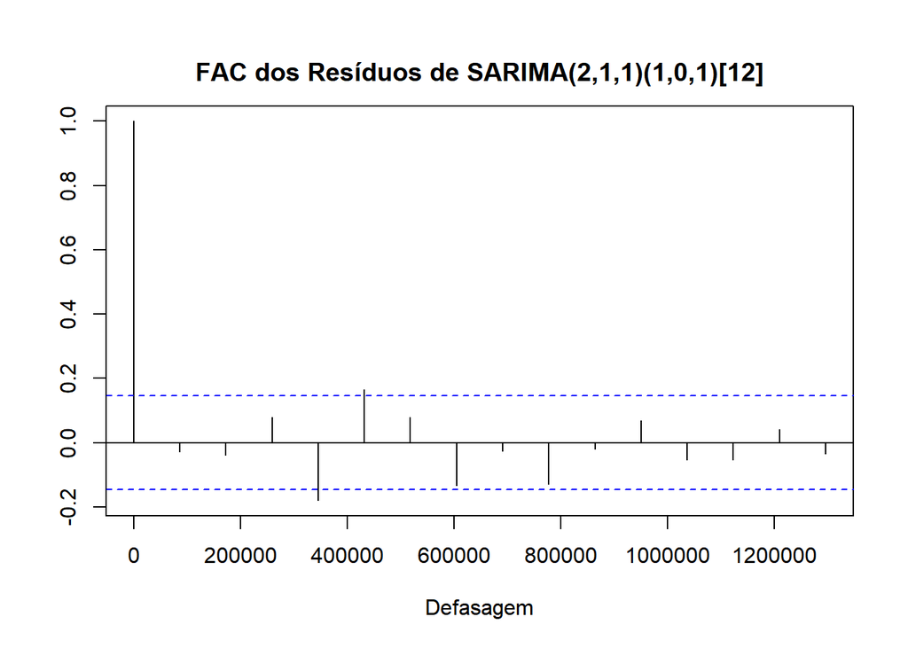

```r
fac_sarima_est <- stats::acf(modelo_fca[[best_aic_fca]]$residuals, na.action = na.pass, plot = FALSE, lag.max = 15)

plot(fac_sarima_est, main = "", ylab = "", xlab = "Defasagem")
title("FAC dos Resíduos de SARIMA(2,1,1)(1,0,1)[12]", adj = 0.5, line = 1)
```

```r
Box.test(modelo_fca[[best_aic_fca]]$residuals,type="Ljung",lag=1)
```

```
##
##  Box-Ljung test
##
## data:  modelo_fca[[best_aic_fca]]$residuals
## X-squared = 0.14223, df = 1, p-value = 0.7061
```

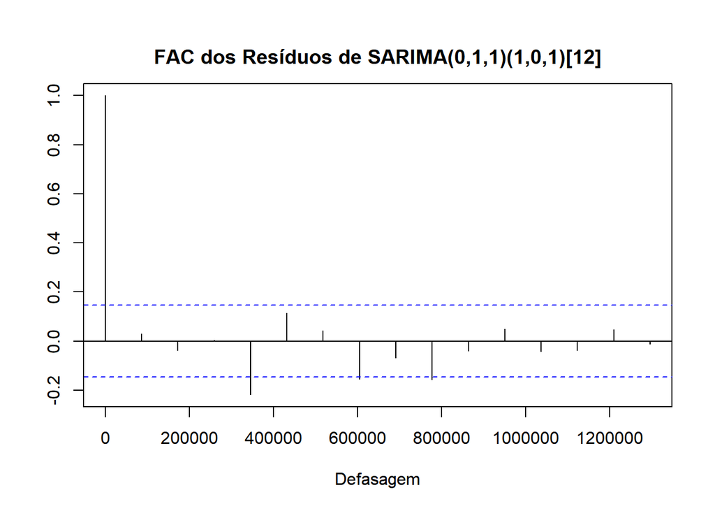

```r
fac_sarima_est2 <- stats::acf(modelo_fca[[best_bic_fca]]$residuals, na.action = na.pass, plot = FALSE, lag.max = 15)

plot(fac_sarima_est2, main = "", ylab = "", xlab = "Defasagem")
title("FAC dos Resíduos de SARIMA(0,1,1)(1,0,1)[12]", adj = 0.5, line = 1)
```

```r
Box.test(modelo_fca[[best_bic_fca]]$residuals,type="Ljung",lag=1)
```

```
##
##  Box-Ljung test
##
## data:  modelo_fca[[best_bic_fca]]$residuals
## X-squared = 0.15317, df = 1, p-value = 0.6955
```

O teste Box-Ljung não rejeita a possibilidade de os resíduos serem não-autocorrelacionados para ambos os modelos, o que, todavia, não significa qe eles certamente não são autocorrelacionados.

### 5.0.2 Teste de heterocedasticidade condicional

$H_0$: quadrado dos resíduos são não-autocorrelacionados

$H_1$: quadrado dos resíduos são autocorrelacionados

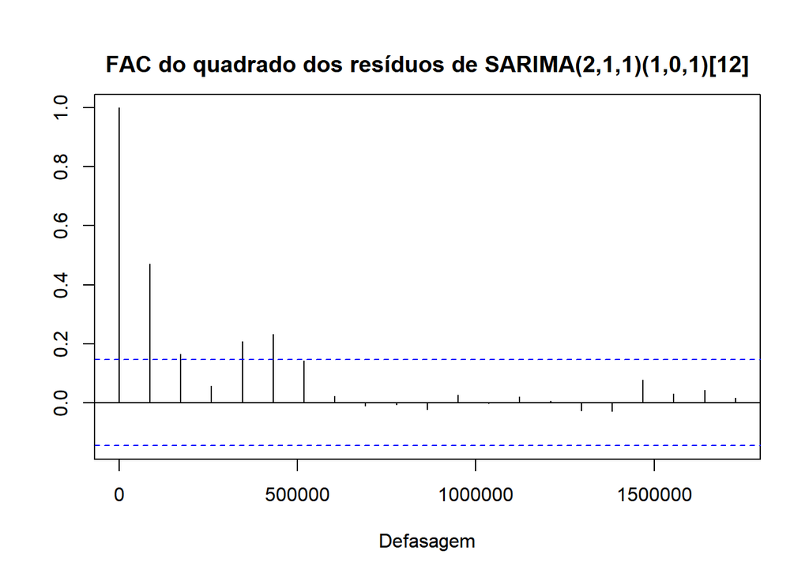

```r
acf_sarima_square <- acf(modelo_fca[[best_aic_fca]]$residuals^2, na.action = na.pass, plot = FALSE, lag.max = 20)

plot(acf_sarima_square, main = "", ylab = "", xlab = "Defasagem")
title("FAC do quadrado dos resíduos de SARIMA(2,1,1)(1,0,1)[12]", adj = 0.5, line = 1)
```

```r
Box.test(modelo_fca[[best_aic_fca]]$residuals^2,type="Ljung",lag=1)
```

```
##
##  Box-Ljung test
##
## data:  modelo_fca[[best_aic_fca]]$residuals^2
## X-squared = 40.456, df = 1, p-value = 2.011e-10
```

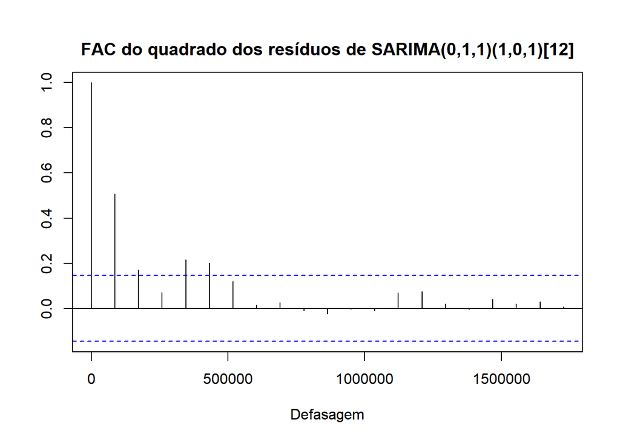

```r
acf_sarima_square <- acf(modelo_fca[[best_bic_fca]]$residuals^2, na.action = na.pass, plot = FALSE, lag.max = 20)

plot(acf_sarima_square, main = "", ylab = "", xlab = "Defasagem")
title("FAC do quadrado dos resíduos de SARIMA(0,1,1)(1,0,1)[12]", adj = 0.5, line = 1)
```

```r
Box.test(modelo_fca[[best_bic_fca]]$residuals^2,type="Ljung",lag=1)
```

```
##
##  Box-Ljung test
##
## data:  modelo_fca[[best_bic_fca]]$residuals^2
## X-squared = 46.996, df = 1, p-value = 7.114e-12
```

O teste Ljung-Box para o quadrado dos resíduos permite rejeitar a hipótese de estes serem não-autocorrelacionados.

### 5.0.3 Teste de normalidade dos resíduos

Análise visual

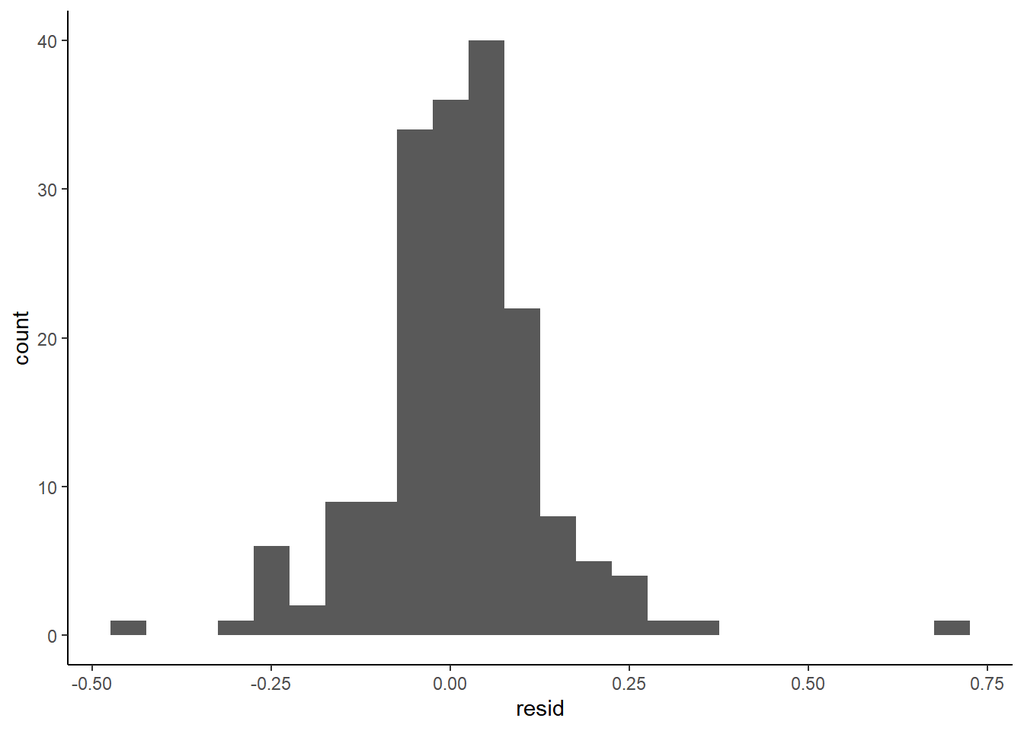

```r
resid_fca <- modelo_fca[[best_aic_fca]]$residuals %>%
  as.data.frame() %>%
  rename(resid = x)

ggplot(data = resid_fca, aes(x = resid)) +
  geom_histogram(binwidth = 0.05) +
  theme_classic()
```

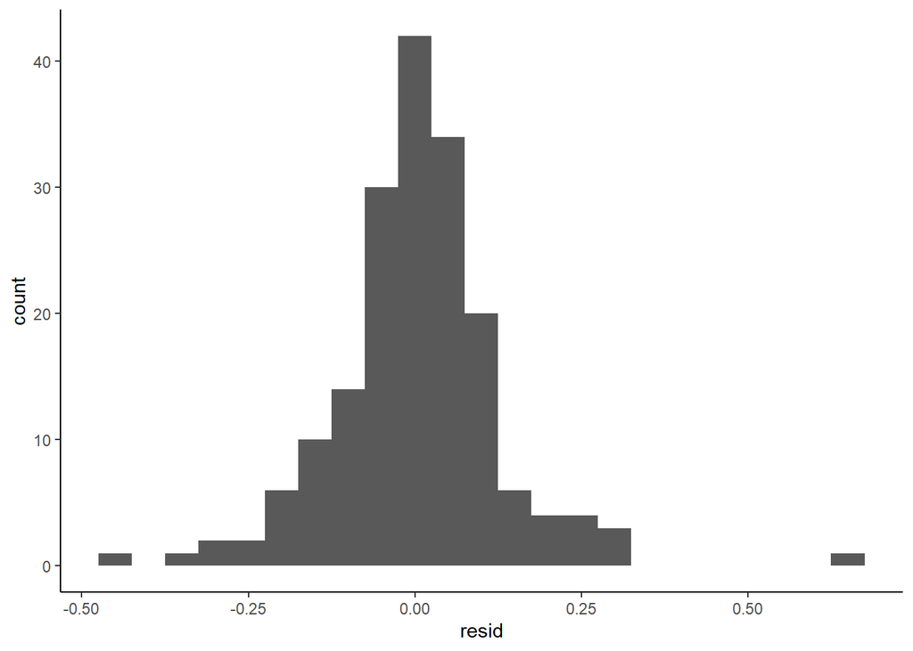

```r
resid_fca <- modelo_fca[[best_bic_fca]]$residuals %>%
  as.data.frame() %>%
  rename(resid = x)

ggplot(data = resid_fca, aes(x = resid)) +
  geom_histogram(binwidth = 0.05) +
  theme_classic()
```

Visualmente, os resíduos de ambas as séries guardam alguma lembrança com a distribuição normal.

**Testes estatísticos**

$H_0$: resíduos são normalmente distribuídos

$H_1$: resíduos não o são

```r
modelo_fca[[best_aic_fca]]$residuals %>%
  na.remove() %>%
  shapiro.test()
```

```
##
##  Shapiro-Wilk normality test
##
## data:  .
## W = 0.92753, p-value = 8.086e-08
```

```r
modelo_fca[[best_aic_fca]]$residuals %>%
  na.remove() %>%
  jarque.bera.test()
```

```
##
##  Jarque Bera Test
##
## data:  .
## X-squared = 249.33, df = 2, p-value < 2.2e-16
```

```r
modelo_fca[[best_bic_fca]]$residuals %>%
  na.remove() %>%
  shapiro.test()
```

```
##
##  Shapiro-Wilk normality test
##
## data:  .
## W = 0.93885, p-value = 6.166e-07
```

```r
modelo_fca[[best_bic_fca]]$residuals %>%
  na.remove() %>%
  jarque.bera.test()
```

```
##
##  Jarque Bera Test
##
## data:  .
## X-squared = 190.63, df = 2, p-value < 2.2e-16
```

No entanto, os testes Shapiro-Wilk e Jarque-Bera permitem, com ampla margem, rejeitar a hipótese de normalidade dos resíduos, convergindo com o teste de heterocedasticidade condicional.

# 6 Previsões

## 6.1 Real vs. estimado

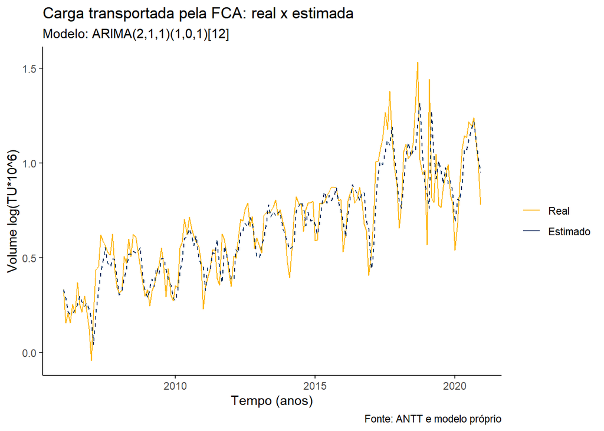

```r
fitted_aic_fca <- stats::fitted(modelo_fca[[best_aic_fca]])
fitted_bic_fca <- stats::fitted(modelo_fca[[best_bic_fca]])
er_fca <- data.frame(data = index(fca_log), real = as.vector(fca_log), estimado_aic = as.vector(fitted_aic_fca), estimado_bic = as.vector(fitted_bic_fca))

ggplot(er_fca, aes(x = data)) +
  scale_color_manual("",
                      breaks = c("Real", "Estimado"),
                      values = c("#FEB712", "#002C5E")) +
  geom_line(aes(y = real, color = "Real")) +
  geom_line(aes(y = estimado_aic, color = "Estimado"), linetype = "dashed") +
  labs(title = "Carga transportada pela FCA: real x estimada", subtitle = "Modelo: ARIMA(2,1,1)(1,0,1)[12]", x = "Tempo (anos)", y = "Volume log(TU*10^6)", caption = "Fonte: ANTT e modelo próprio") +
  theme(axis.text.x = element_text(angle = 90, hjust = 1)) +
  theme_classic()
```

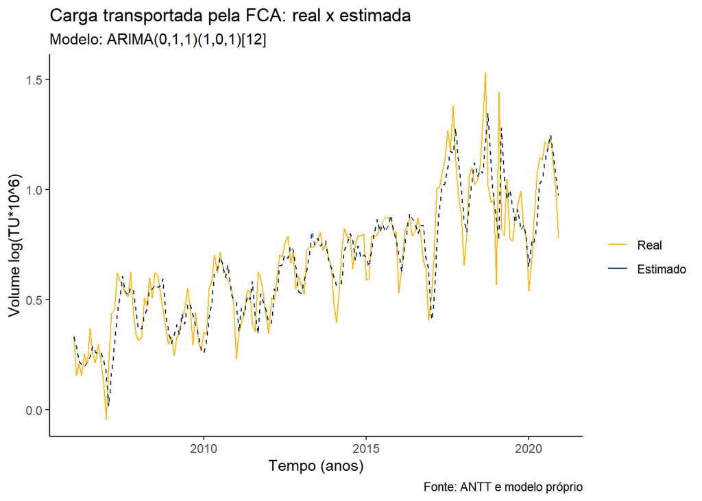

```r
ggplot(er_fca, aes(x = data)) +
  scale_color_manual("",
                      breaks = c("Real", "Estimado"),
                      values = c("#FEB712", "#002C5E")) +
  geom_line(aes(y = real, color = "Real")) +
  geom_line(aes(y = estimado_bic, color = "Estimado"), linetype = "dashed") +
  labs(title = "Carga transportada pela FCA: real x estimada", subtitle = "Modelo: ARIMA(0,1,1)(1,0,1)[12]", x = "Tempo (anos)", y = "Volume log(TU*10^6)", caption = "Fonte: ANTT e modelo próprio") +
  theme(axis.text.x = element_text(angle = 90, hjust = 1)) +
  theme_classic()
```

```r
aa_fca <- auto.arima(fca_log, seasonal = TRUE)
summary(aa_fca)
```

```
## Series: fca_log
## ARIMA(1,1,1)
##
## Coefficients:
##          ar1      ma1
##       0.6213  -0.9270
## s.e.  0.0718   0.0286
##
## sigma^2 estimated as 0.01965:  log likelihood=98.33
## AIC=-190.67   AICc=-190.53   BIC=-181.1
##
## Training set error measures:
##                      ME      RMSE       MAE     MPE     MAPE      MASE
## Training set 0.01928606 0.1390225 0.1014134 2.07164 20.05027 0.1519018
##                     ACF1
## Training set -0.05346681
```

```r
coeftest(aa_fca)
```

```
##
## z test of coefficients:
##
##      Estimate Std. Error  z value  Pr(>|z|)
## ar1  0.621330   0.071839   8.6489 < 2.2e-16 ***
## ma1 -0.926962   0.028551 -32.4673 < 2.2e-16 ***
## ---
## Signif. codes:  0 '***' 0.001 '**' 0.01 '*' 0.05 '.' 0.1 ' ' 1
```

## 6.2 Previsão

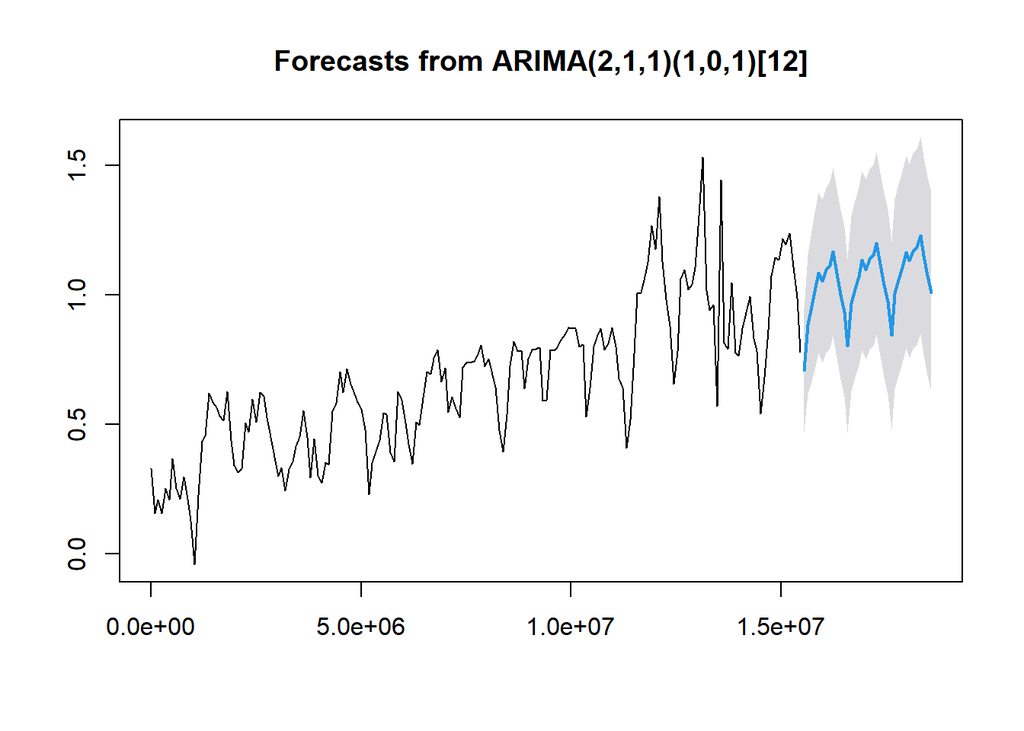

```r
f1_fca <- forecast::forecast(object = modelo_fca[[best_aic_fca]], h =36, level = 0.95)
plot(f1_fca)
```

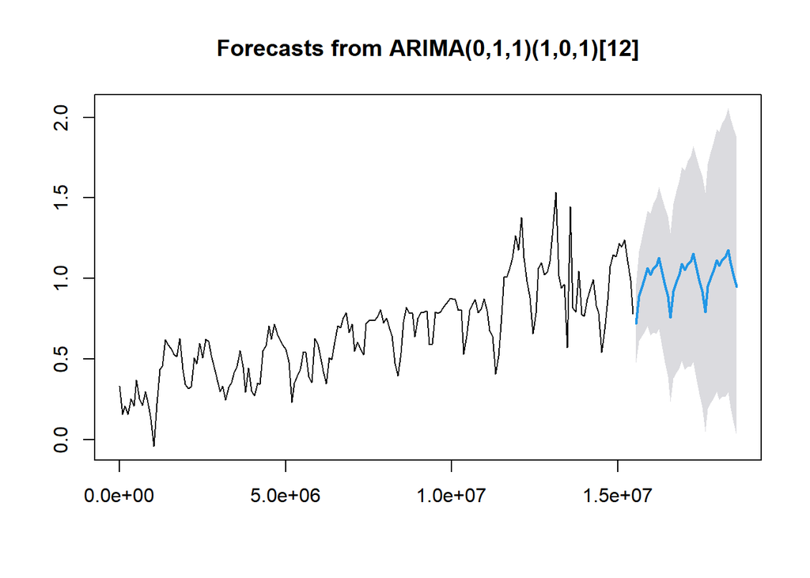

```r
f2_fca <- forecast::forecast(object = modelo_fca[[best_bic_fca]], h = 36, level = 0.95)
plot(f2_fca)
```

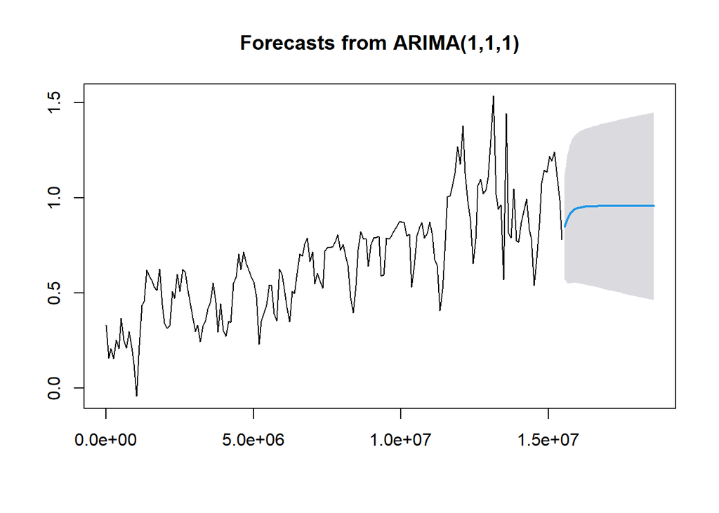

```r
f3_fca <- forecast::forecast(object = aa_fca, h = 36, level = 0.95)
plot(f3_fca)
```